# Case Study R Markdown

SSD

2024-07-26

# Cyclistic Bike-Share Analysis Case Study

This is Cyclistic bike-share analysis Case Study! In this project, there is a fictional company, Cyclistic and to navigate there speedy success, analysis is done using their Bike-Share data. This analysis follows the six steps of the data analysis process: Ask, Prepare, Process, Analyze, Share, and Act.

## Table of Contents

- Introduction
- Data Analysis Process
  - Ask
  - Prepare
  - Process
  - Analyze
  - Share
  - Act
- Results
- Conclusion

## Introduction

This case study analyzes Cyclistic’s bike-share data to uncover insights that can help the company improve its services and attract more users. The data analysis aims to understand trends, user behavior, and preferences.

## Data Analysis Process

### Ask

**Key Questions:**

- How do annual members and casual riders use Cyclistic bikes differently?
- Why would casual riders buy Cyclistic annual memberships?
- When will the demand for memberships increase?
- Who will use bikes more often and for what purpose?

### Prepare

- **Data Source:** The datasets have a different name because Cyclistic is a fictional company. The data has been made available by Motivate International Inc. under this [license](https://divvybikes.com/data-license-agreement).

### Analyze

Data analysis is performed using various techniques, including aggregation and visualization, to identify patterns and trends.

### Share

Visualizations and summaries of key insights are created and shared to communicate findings effectively.

### Act

Based on the analysis, actionable recommendations are provided to help Cyclistic improve its services and marketing strategies.

## Code

```r
library(tidyverse)
library(janitor)
```

```r
library(ggplot2)
library(lubridate)
library(dplyr)
```

### Load data

```r
aug23 <- read.csv("D:/Money/Google Data Analytics/Case Study 1/Datasets/aug23.csv")
oct23 <- read.csv("D:/Money/Google Data Analytics/Case Study 1/Datasets/oct23.csv")
nov23 <- read.csv("D:/Money/Google Data Analytics/Case Study 1/Datasets/nov23.csv")
dec23 <- read.csv("D:/Money/Google Data Analytics/Case Study 1/Datasets/dec23.csv")
jan24 <- read.csv("D:/Money/Google Data Analytics/Case Study 1/Datasets/jan24.csv")
feb24 <- read.csv("D:/Money/Google Data Analytics/Case Study 1/Datasets/feb24.csv")
mar24 <- read.csv("D:/Money/Google Data Analytics/Case Study 1/Datasets/mar24.csv")
apr24 <- read.csv("D:/Money/Google Data Analytics/Case Study 1/Datasets/apr24.csv")
may24 <- read.csv("D:/Money/Google Data Analytics/Case Study 1/Datasets/may24.csv")
jun24 <- read.csv("D:/Money/Google Data Analytics/Case Study 1/Datasets/jun24.csv")
jul24 <- read.csv("D:/Money/Google Data Analytics/Case Study 1/Datasets/july24.csv")
```

### Combine data into one dataframe

```r
data_total <- rbind(aug23, oct23, nov23, dec23, jan24, feb24, mar24, apr24, may24, jun24, jul24)
rm(aug23, oct23, nov23, dec23, jan24, feb24, mar24, apr24, may24, jun24, jul24)
```

### Data cleaning

```r
data_total <- select(data_total, -c(start_lat, start_lng, end_lat, end_lng, start_station_id, end_station_id, end_station_name))
```

### Data transformation

```r
data_total$date <- as.Date(data_total$started_at)
data_total$month <- format(as.Date(data_total$date), "%m")
data_total$day_of_week <- format(as.Date(data_total$date), "%A")
data_total$ride_length <- (as.double(difftime(data_total$ended_at, data_total$started_at)))/60
data_total$ride_length <- as.numeric(as.character(data_total$ride_length))
```

### Summary statistics

```r
summary(data_total$ride_length)
```

```
##     Min.  1st Qu.   Median     Mean  3rd Qu.     Max.
## -2748.32     5.60     9.85    18.26    17.53 51461.40
```

```r
aggregate(data_total$ride_length ~ data_total$member_casual, FUN = mean)
```

```
##   data_total$member_casual data_total$ride_length
## 1                   casual               27.38600
## 2                   member               13.02419
```

```r
aggregate(data_total$ride_length ~ data_total$member_casual, FUN = median)
```

```
##   data_total$member_casual data_total$ride_length
## 1                   casual              12.350000
## 2                   member               8.766667
```

```r
aggregate(data_total$ride_length ~ data_total$member_casual, FUN = max)
```

```
##   data_total$member_casual data_total$ride_length
## 1                   casual                51461.4
## 2                   member                 1559.8
```

```r
aggregate(data_total$ride_length ~ data_total$member_casual, FUN = min)
```

```
##   data_total$member_casual data_total$ride_length
## 1                   casual              -160.0333
## 2                   member             -2748.3167
```

### Visualization: Rides per Day of Week

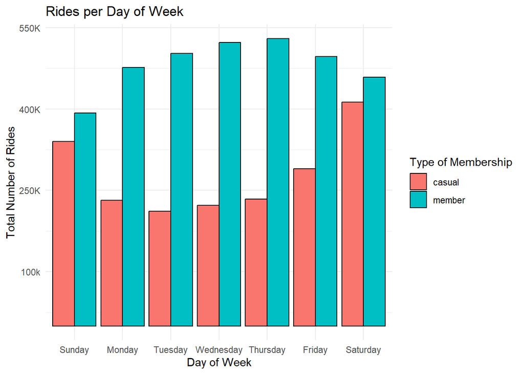

```r
data_total$day_of_week <- ordered(data_total$day_of_week, levels = c("Sunday", "Monday", "Tuesday", "Wednesday", "Thursday", "Friday", "Saturday"))
data_total %>%
  group_by(member_casual, day_of_week) %>%
  summarise(number_of_rides = n()) %>%
  arrange(member_casual, day_of_week) %>%
  ggplot(aes(x = day_of_week, y = number_of_rides, fill = member_casual)) +
  geom_col(position = "dodge", color = "black") +
  theme_minimal() +
  labs(x = 'Day of Week', y = 'Total Number of Rides', title = 'Rides per Day of Week', fill = 'Type of Membership') +
  scale_y_continuous(breaks = c(100000, 250000, 400000, 550000), labels = c("100k", "250K", "400K", "550K"))
```

### Visualization: Rides per Month

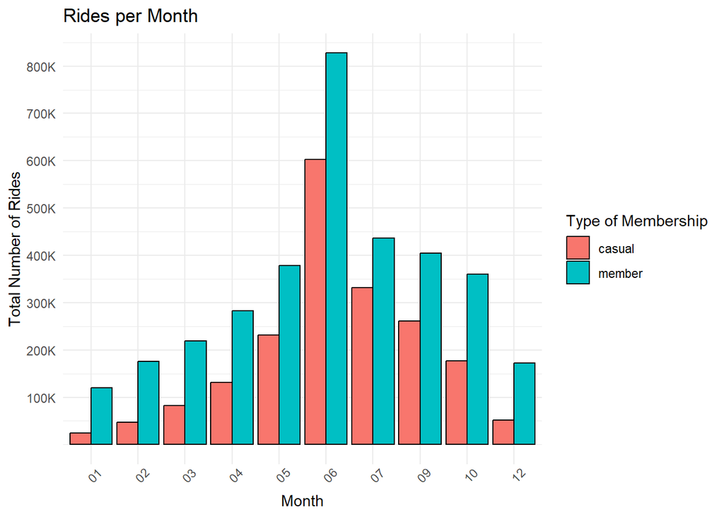

```r
data_total %>%
  group_by(member_casual, month) %>%
  summarise(total_rides = n(), `average_duration_(mins)` = mean(ride_length)) %>%
  arrange(member_casual) %>%
  ggplot(aes(x = month, y = total_rides, fill = member_casual)) +
  geom_col(position = "dodge", color = "black") +
  theme_minimal() +
  labs(x = "Month", y = "Total Number of Rides", title = "Rides per Month", fill = "Type of Membership") +
  scale_y_continuous(breaks = c(100000, 200000, 300000, 400000, 500000, 600000, 700000, 800000),
                     labels = c("100K", "200K", "300K", "400K", "500K", "600K", "700K", "800K")) +
  theme(axis.text.x = element_text(angle = 45))
```

### Visualization: Bike Popularity among Member Types

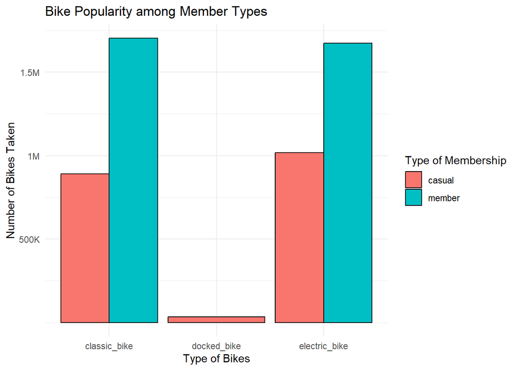

```r
data_total %>%
  ggplot(aes(x = rideable_type, fill = member_casual)) +
  geom_bar(position = "dodge", color = "black") +
  theme_minimal() +
  labs(x = "Type of Bikes", y = "Number of Bikes Taken", title = 'Bike Popularity among Member Types', fill = 'Type of Membership') +
  scale_y_continuous(breaks = c(500000, 1000000, 1500000), labels = c("500K", "1M", "1.5M"))
```

### Summary: Rides by Member Type and Day of Week

[figure not shown]

```r
data_total %>%
  group_by(member_casual, day_of_week) %>%
  summarise(number_of_rides = n(), average_duration = mean(ride_length)) %>%
  arrange(member_casual, day_of_week) %>%
  ggplot(aes(x = day_of_week, y = average_duration, fill = member_casual)) +
  geom_col(position = "dodge", color = "black") +
  theme_minimal() +
  labs(x = 'Days of the week', y = 'Average duration - Hrs', title = 'Average ride time per week', fill = 'Type of Membership')
```

## Results

- **Rides per Day of Week:** Visualized the total number of rides per day of the week, broken down by membership type.
- **Rides per Month:** Analyzed the total number of rides and average ride duration per month, segmented by membership type.
- **Bike Popularity among Member Types:** Examined the popularity of different bike types among casual and member riders.
- **Rides by Member Type and Day of Week:** Summarized the number of rides and average ride duration by membership type and day of the week.

## Conclusion

The analysis provided insights into how different user groups interact with the Cyclistic bike-share service. These findings can help Cyclistic tailor its marketing strategies to convert casual riders into annual members and optimize its services for better user satisfaction.